### Draft 1 of BIOS 611 Project 1

#### 1. A description of the data set.

There are two datasets involved in this analysis. The first is data associated with one coral “core” collected from the Florida Keys in 2014. The analysis of coral cores is similar to that of analyzing the rings on a tree - they provide information about a coral’s annual growth over time. This dataset includes linear extension data, calcification, and skeletal density for each year since 1890. By comparing historical coral growth to environmental data, we can better understand the relationship between the environmental conditions at a given point in history and variations in coral growth. Along this same vein, the second dataset that I am using is of all storms that came within 500km of this coral core since 1988 (although there is some less detailed data available for earlier years if I decide I want to explore it). This dataset also includes other values such as wind speed, storm radius, etc.

This data set was obtained from my research advisor, so I’m excited to explore it and potentially contribute to our understanding of the effect of storms on coral growth.

#### Some preliminary figures.

**Let’s first find out how the frequency of storms has varied from 1988-2015.**

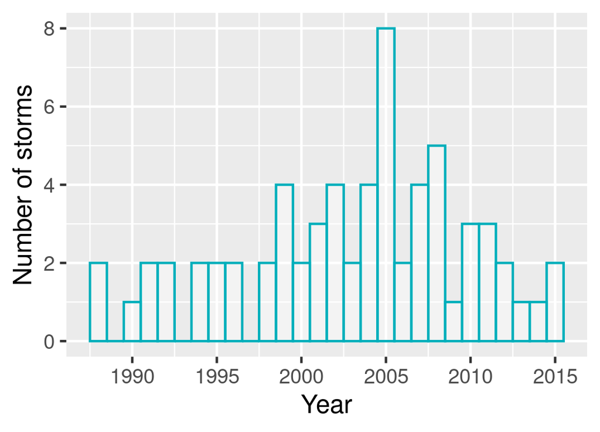

storms_frequency

From 1988-1998, it seems like there were no more than 2 storms/year coming in vicinity of this particular coral, and some years there were no storms at all. We start to see a gradual increase in the frequency of storms, with a whopping 8 storms coming in vicinity of the coral in 2005! Since 1997 there hasn’t been one year with 0 storms coming near this coral. However, it seems like there has been a decrease since 2005. Maybe there was a unique atmospheric event around 2005 that led to an increase in storm frequency? Or maybe this is just an outlier.

**Let’s overlay storm category, which is a measure of strength based upon the sea level pressure of the storm, on the histogram above.**

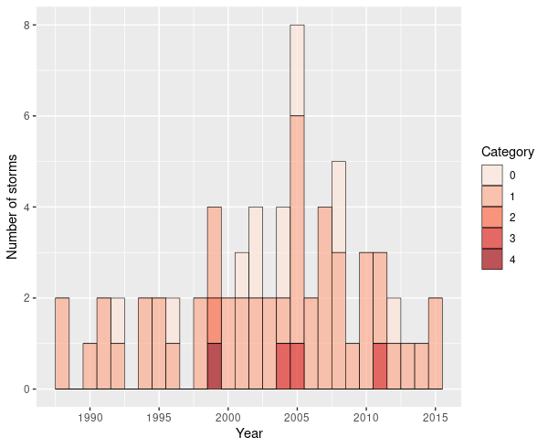

storms_frequency_category

It seems like the frequency of higher category storms increased slightly in the early 2000s.

**I’d like to see if the increase in storm frequency/intensity in the early 2000s had an impact on coral growth.**

**First, I’ll plot the change in density, calcification, and linear extension over time (1890-2014).**

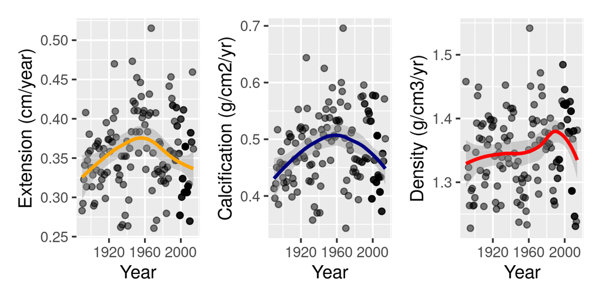

annualgrowth_compiled

**It might be more useful to view this data by the change in each of the growth variables per year.**

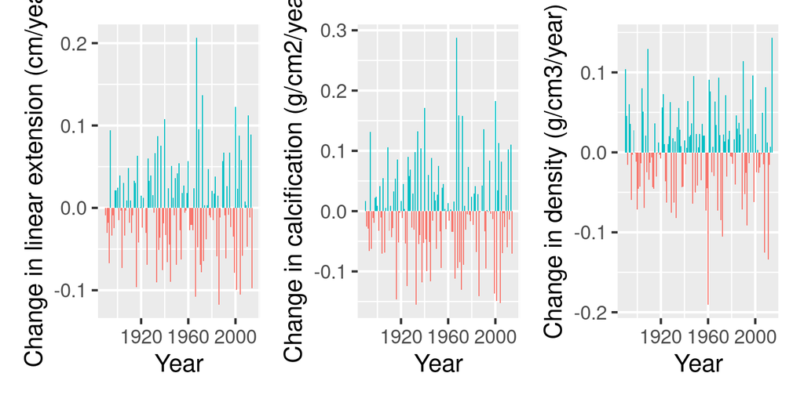

annualchange_compiled

No clear patterns in the plots above.

**Zooming in on data since 1988** (dates that we have both growth and storm data)

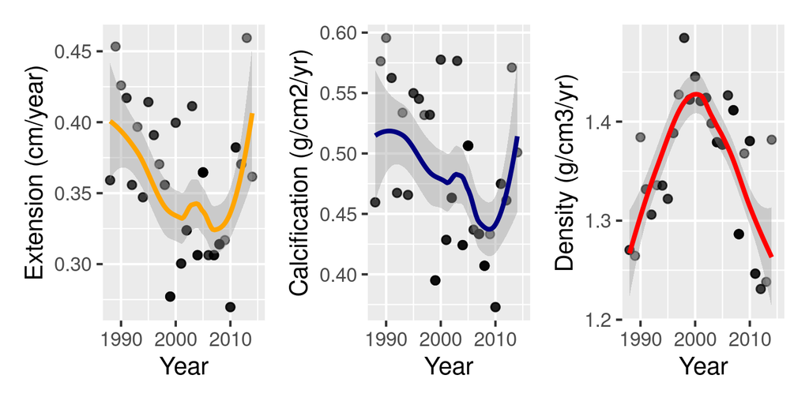

annualgrowth_since1988_compiled